# Pengenalan Sistem Terintegrasi

09 September 2025

## Do’a Belajar

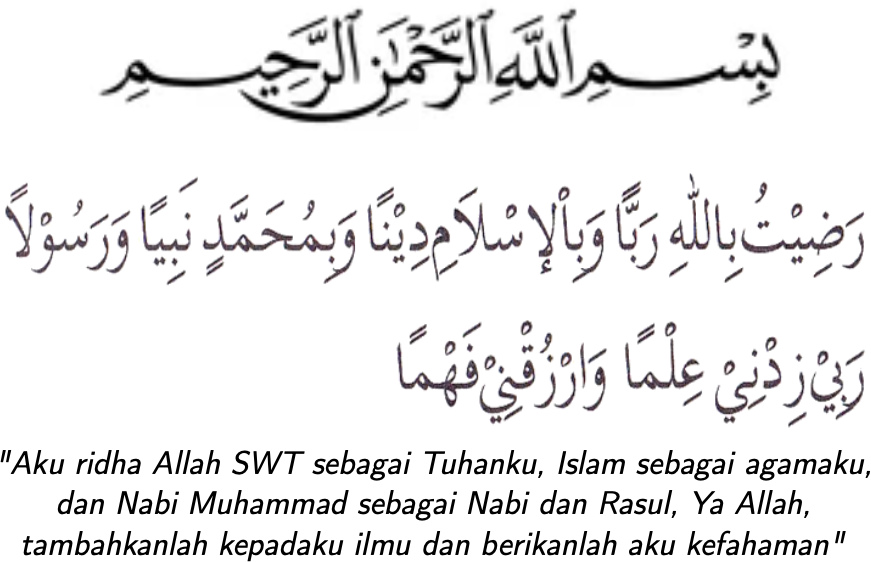

## Latar Belakang

- Saat ini, seluruh proses bisnis sudah terdigitalisasi.
- Sebagian besar perusahaan memiliki kebutuhan digital yang jauh lebih besar daripada ekpektasi awal.
- Mereka membutuhkan berbagai macam produk hardware dan software untuk memenuhi kebutuhan digitalisasi tersebut.
- Produk-produk tersebut didesain secara terpisah, tetapi ada kebutuhan untuk membuat semua produk tersebut bisa bekerja sama untuk mendapatkan sebuah proses bisnis digital yang lebih efisien.

## Definisi

- **Integrasi Sistem** adalah proses menghubungkan atau menggabungkan berbagai macam komponen menjadi sebuah elemen tunggal yang dapat melakukan semua fungsi tertentu
- Koneksi dari berbagai macam fitur melalui integrasi sistem menjadikan sebuah sistem utama bisa menjalankan fungsionalitas khusus yang dibutuhkan oleh sebuah perusahaan.

## Integrasi sistem bisa dalam bentuk

[figure not shown]

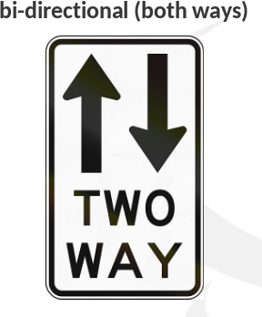

Secara singkatnya, data ataupun fungsionalitas harus bisa berjalan dengan lancar antar fitur/sistem yang diintegrasikan sehingga mereka bisa berkomunikasi secara optimal.

## Tantangan pada Integrasi Sistem

- Dulu, integrasi sistem seringnya adalah sebuah pekerjaan kompleks yang sangat sulit dan melelahkan untuk dikerjakan.
- Sistem ataupun aplikasi dari berbagai macam vendor/provider membutuhkan solusi integrasi yang custom-coded dan point-to-point
- Solusi ini terbukti tidak fleksible, rapuh, dan membutuhkan maintenance secara terus menerus.
- Setiap ada software update ataupun perubahan pada proses bisnis bisa merusak seluruh integrasi sistem.
- Loncat ke jaman sekarang, sudah banyak solusi integrasi yang baik, robust dan canggih; yang memungkinkan teknologi-teknologi baru seperti cloud, big-data, dan IoT berkomunikasi dengan efektif dan efisien satu sama lain.

## Kenapa sistem harus diintegrasikan?

- Sebuah proses baru mungkin saja ditambahkan atau menjadi lebih kompleks ketika sebuah perusahaan berkembang.
- Akhirnya, berbagai macam fungsi bisnis bisa berada pada beberapa sistem yang terpisah dimana sistem tersebut tidak berkomunikasi ataupun berbagi data satu sama lain. Hasilnya: Proses menjadi tidak efisien dan mahal.
- Sebaliknya, dengan mengintegrasikan proses bisnis pada sebuah platform tunggal, semua fungsi pada rantai proses bisnis bisa digabungkan menjadi satu sistem sehingga akan meningkatkan produktifitas dan kualitas operasional. Hal tersebut dikarenakan semakin lancarnya aliran informasi.

## Jenis Integrasi Sistem

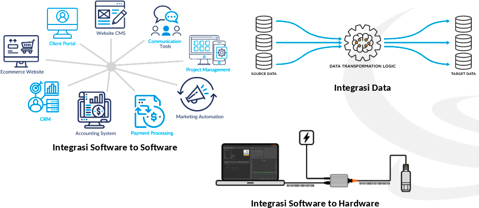

## INTEGRASI SOFTWARE TO SOFTWARE

## Definisi Software Integration

- Integrasi perangkat lunak adalah proses menghubungkan berbagai jenis sub-sistem perangkat lunak untuk menyatukan pengumpulan data. Hal ini digunakan untuk memecahkan masalah data yang terisolasi.
- Proses integrasi dapat disederhanakan dengan penggunaan alat integrasi modern.
- Sebelum memulai integrasi sistem, tim bisnis harus mempertimbangkan sistem mana yang perlu diintegrasikan, alat apa yang sesuai dengan kebutuhan mereka, dan sumber data mana yang dapat memperoleh manfaat dari integrasi.

## Why?

Organisasi akan melakukan integrasi perangkat lunak untuk berbagai alasan:

- Bisnis mungkin perlu menggabungkan sistem yang berbeda menjadi satu.
- Bisnis mungkin ingin beralih dari solusi lama ke aplikasi modern.
- Perusahaan juga akan mengintegrasikan solusi perangkat lunak untuk meningkatkan fungsionalitas mereka secara keseluruhan.

## How to get started?

Untuk memulai, Kita harus menemukan jawaban atas pertanyaan-pertanyaan ini:

1. What type of software will you integrate?
   - Apakah menggunakan In-house software, SaaS?
   - Perusahaan kecil biasanya langsung menjatuhkan pilihan ke SaaS
   - Baik perusahaan kecil ataupun besar, jika mereka menggunakan in-house software, maka dibutuhkan tim engineer untuk membangun sebuah software untuk proses integrasi. Jika merasa terlalu kompleks dan tidak ada sumber daya, bisa menggunakan [IPaaS (Integration Platform as a Service)](https://www.gartner.com/reviews/market/enterprise-integration-platform-as-a-service)
   - Aplikasi berbasis cloud (SaaS) menjadikan proses integrasi menjadi lebih mudah. Sebagian besar dari mereka menyediakan API umum yang bisa diakses secara publik.

## How to get started? (contd.)

1. Which integration software do you need?
   - Native/in-app integration?
2. Which type of data needs integration?
   - Ketika kita berbicara tentang data, kita dapat mengacu pada angka, orang, perusahaan, produk… apa saja! Untuk menyiapkan integrasi, Anda perlu mengidentifikasi bagian mana dari dua atau lebih database Anda yang masuk akal untuk digabungkan.

## Software integration types

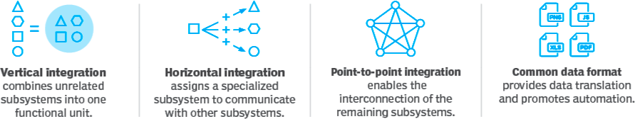

1. Vertical Integration
2. Horizontal Integration
3. Star Integration (Point-to-point integration)
4. Common data format integration

## 1. Vertical Integration

- Berbeda dengan integrasi horizontal, integrasi vertikal merupakan solusi jangka pendek dan dianggap sebagai opsi yang cepat dan murah untuk penyatuan perangkat lunak.
- Perusahaan harus mengembangkan entitas fungsional untuk sistem perangkat lunak mereka dan menyinkronkannya secara vertikal.
- Kelebihan
  - Kontrol yang lebih baik atas proses bisnis
  - Daya saing yang dimaksimalkan
  - Bagi peritel, ini juga dapat membantu merampingkan manajemen rantai pasokan, meningkatkan komunikasi dengan vendor, dan mengurangi biaya operasional
- Kekurangan
  - Integrasi vertikal akan menciptakan bagian untuk menskalakan perangkat lunak. Ini berarti bahwa informasi tidak akan dibagikan dengan benar dan akan terisolasi di setiap sistem.

## 2. Horizontal Integration

Integrasi horizontal, yang juga dikenal sebagai Enterprise Service Bus, adalah metode membangun sistem untuk komunikasi. Integrasi horizontal akan mengurangi jumlah tautan untuk setiap subsistem. Pendekatan ini akan memungkinkan fleksibilitas, di mana tim dapat menambah, menghapus, atau menyesuaikan sistem tanpa mengganggu komponen lainnya.

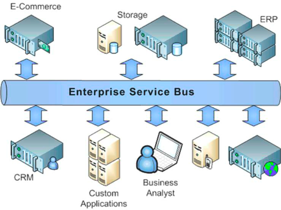

## 3. Star Integration

Integrasi bintang adalah proses pengembangan koneksi dalam semua subsistem perangkat lunak. Namanya berasal dari fakta bahwa ketika semua sistem saling berhubungan, diagramnya akan terlihat seperti bintang.

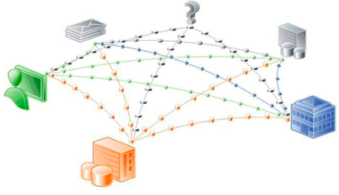

## 4. Common data format integration

Format data umum adalah pendekatan untuk integrasi perangkat lunak yang memungkinkan bisnis untuk menghindari penggunaan adaptor saat mengonversi atau mengangkut data. Agar metode ini efektif, format data dari satu sistem harus diterima oleh sistem lainnya. Sistem EAI (Enterprise Application Integration) biasanya, berisi layanan transformasi data yang memungkinkan konversi antara format aplikasi yang spesifik dan umum. adaptor mengonversi data dari format aplikasi ke format umum dan menerapkan transformasi semantik pada data tersebut.

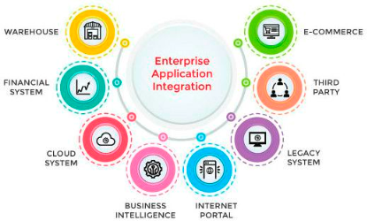

## Contoh software integration

Berikut adalah beberapa contoh integrasi perangkat lunak:

1. Mengintegrasikan situs web Anda dengan platform media sosial seperti Facebook dan Twitter sehingga pengguna dapat berbagi konten dari situs Anda.
2. Mengintegrasikan sistem akuntansi Anda dengan platform e-commerce seperti Magento atau Shopify sehingga pesanan dapat diproses secara otomatis ketika pelanggan melakukan pemesanan online.
3. Mengintegrasikan sistem CRM Anda dengan platform pemasaran email seperti MailChimp sehingga email pemasaran dapat dikirim secara otomatis ketika ada prospek baru yang mendaftar ke layanan Anda.
4. Mengintegrasikan Google Analytics ke dalam WordPress sehingga Anda dapat melacak aktivitas pengunjung di situs web Anda tanpa berpindah-pindah alat.

## INTEGRASI SOFTWARE TO HARDWARE

## Software to Hardware Example

- Integrasi perangkat keras + perangkat lunak: IoT (Internet of Things)
- Melalui komputasi berbiaya rendah, cloud, big data, analitik, dan teknologi seluler, benda-benda fisik dapat berbagi dan mengumpulkan data dengan campur tangan manusia yang minimal

## Teknologi apa saja yang memungkinkan menggunakan IoT?

1. Access to low-cost, low-power sensor technology.
2. Connectivity
3. Cloud computing platforms
4. Machine learning and analytics
5. Conversational artificial intelligence (AI), like Alexa, Siri, Bixby

## What is industrial IoT?

- Industrial IoT (IIoT) mengacu pada penerapan teknologi IoT dalam pengaturan industri, terutama yang berkaitan dengan instrumentasi dan kontrol sensor dan perangkat yang menggunakan teknologi cloud.
- IoT terkadang disebut sebagai gelombang keempat revolusi industri, atau Industri 4.0. Berikut ini adalah beberapa penggunaan umum untuk IoT:
1. Smart manufacturing
2. Connected assets and preventive and predictive maintenance
3. Smart power grids
4. Smart cities
5. Connected logistics
6. Smart digital supply chains

## Industri apa saja yang bisa mendapatkan manfaat dari IoT?

Manufacturing Tujuan utama pemantauan mesin di industri adalah untuk memaksimalkan keuntungan, meningkatkan tingkat produktivitas mereka yang bekerja di lantai pabrik, dan meminimalkan biaya - tanpa mengorbankan kualitas produk atau layanan

[figure not shown]

## Industri apa saja yang bisa mendapatkan manfaat dari IoT?

Automotive Sistem kendaraan yang terhubung dapat memantau kualitas udara, arus lalu lintas, atau bahkan kondisi jalan secara real-time. Menerapkan teknologi IoT dapat membantu bisnis transportasi mendapatkan keuntungan dari beberapa hal berikut: 1. Cargo tracking 2. Manajemen armada 3. Predictive maintenance 4. Perencanaan rute yang optimal 5. Pemantauan status pengemudi

[figure not shown]

## INTEGRASI DATA

## The natural complexity of data interfaces

Rata-rata lingkungan komputasi perusahaan terdiri dari ratusan atau bahkan ribuan sistem komputer yang berbeda dan berubah-ubah yang telah dibangun, dibeli, dan diakuisisi

Dengan semakin banyaknya sistem yang ditambahkan ke dalam portofolio organisasi, jumlah dan kompleksitas antarmuka di antara sistem-sistem tersebut bertambah secara dramatis, sehingga membuat pengelolaan antarmuka tersebut menjadi sangat berat

Jumlah antarmuka antara aplikasi dan sistem dapat menjadi faktor eksponensial dari jumlah sistem.

Organisasi yang mengembangkan antarmuka tanpa strategi integrasi data perusahaan dapat dengan cepat menemukan bahwa mengelola sejumlah besar antarmuka adalah hal yang mustahil

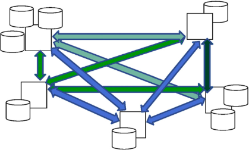

## Mengintegrasikan ke dalam format umum-mengubah data

Biasanya, bagian yang paling rumit dan sulit dalam mengintegrasikan data adalah mengubah data ke dalam format yang umum.

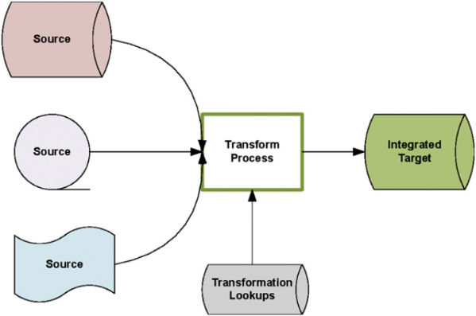

## Memindahkan data dari satu sistem ke sistem lainnya

Ketika sebuah aplikasi dalam sebuah organisasi diganti, baik dengan aplikasi kustom baru atau dengan paket yang dibeli, data dari sistem lama perlu dimigrasikan ke aplikasi baru.

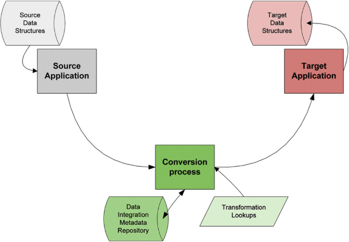

## Memindahkan data di dalam organisasi

sangat penting bagi organisasi bahwa aplikasi-aplikasi dalam sebuah organisasi dapat berbagi informasi di antara mereka. Aplikasi yang berdiri sendiri dan independen yang tidak berbagi data dengan bagian lain dari organisasi menjadi semakin tidak berguna.

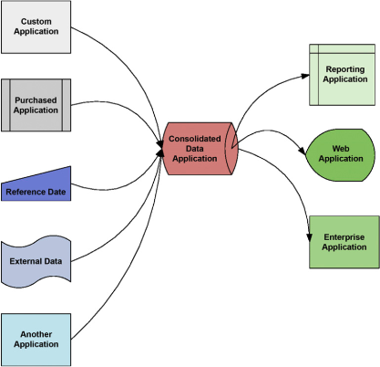

## Menarik informasi dari data yang tidak terstruktur

Sekarang, sangat penting bagi organisasi untuk mengintegrasikan data basis data (atau terstruktur) mereka dengan data dalam dokumen, email, situs web, media sosial, file audio, dan video. Istilah umum untuk data di luar basis data adalah data tidak terstruktur.

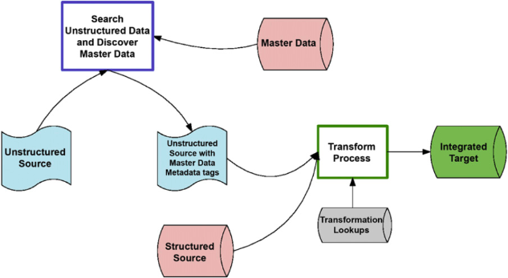

## Penutup

[figure not shown]